# Study of Major Weather Events in USA and Their Effects in Human Life and Economy

Qing Deng

Oct 25 2015

# Synopsis

- Storms and other severe weather events can cause both public health and economic problems for communities and municipalities. Many severe events can result in fatalities, injuries, and property damage, and preventing such outcomes to the extent possible is a key concern.
- This project involves exploring the U.S. National Oceanic and Atmospheric Administration’s (NOAA) storm database. This database tracks characteristics of major storms and weather events in the United States, including when and where they occur, as well as estimates of any fatalities, injuries, and property damage.
- This report serves to find the evens that lead to the most impact on fatalities, injuries and property damage.

# Data source

The data for this assignment come in the form of a comma-separated-value file compressed via the bzip2 algorithm to reduce its size. You can download the file from the course web site:

[Storm Data](https://d396qusza40orc.cloudfront.net/repdata%2Fdata%2FStormData.csv.bz2)[47MB]

There is also some documentation of the database available. Here you will find how some of the variables are constructed/defined.

- National Weather Service [Storm Data Documentation](https://d396qusza40orc.cloudfront.net/repdata%2Fpeer2_doc%2Fpd01016005curr.pdf)
- National Climatic Data Center Storm Events [FAQ](https://d396qusza40orc.cloudfront.net/repdata%2Fpeer2_doc%2FNCDC%20Storm%20Events-FAQ%20Page.pdf)

The events in the database start in the year 1950 and end in November 2011. In the earlier years of the database there are generally fewer events recorded, most likely due to a lack of good records. More recent years should be considered more complete.

# Data Processing

## read the data

```r
 setwd("/Users/Richard/Desktop/Rcourse")
```

Download the file and read into R.

```r
url <- "https://d396qusza40orc.cloudfront.net/repdata%2Fdata%2FStormData.csv.bz2"
#download.file(url,"/Users/Richard/Desktop/Rcourse/data/reproducible_research/stormdata.bz2")
data <- read.csv("/Users/Richard/Desktop/Rcourse/data/reproducible_research/stormdata.bz2")
```

## Exploring the data

```r
dim(data)
```

```
## [1] 902297     37
```

let’s see how many missing vlues for each column.

```r
library(plyr)
nmising <- function(x){sum(is.na(x))}
sapply(data,nmising)
```

```
##    STATE__   BGN_DATE   BGN_TIME  TIME_ZONE     COUNTY COUNTYNAME
##          0          0          0          0          0          0
##      STATE     EVTYPE  BGN_RANGE    BGN_AZI BGN_LOCATI   END_DATE
##          0          0          0          0          0          0
##   END_TIME COUNTY_END COUNTYENDN  END_RANGE    END_AZI END_LOCATI
##          0          0     902297          0          0          0
##     LENGTH      WIDTH          F        MAG FATALITIES   INJURIES
##          0          0     843563          0          0          0
##    PROPDMG PROPDMGEXP    CROPDMG CROPDMGEXP        WFO STATEOFFIC
##          0          0          0          0          0          0
##  ZONENAMES   LATITUDE  LONGITUDE LATITUDE_E LONGITUDE_    REMARKS
##          0         47          0         40          0          0
##     REFNUM
##          0
```

make all the variables names to lower case.

```r
names(data)<- tolower(names(data))
```

## Calculation

1. calculate the total casuality

```r
library(dplyr)
data$casuality <- data$injuries+data$fatalities
info <- data %>% group_by(evtype) %>% summarize(total=sum(casuality))
info <- info[order(info$total, decreasing = T),][1:10,]
info <- info[order(info$evtype),]
```

2. calculate the total ecnomic loss

```r
data$propdmgexp <- as.character(data$propdmgexp)
data$propdmgexp[data$propdmgexp=="K"] <- 1000
data$propdmgexp[data$propdmgexp=="M"]=1000000
data$propdmgexp[data$propdmgexp=="B"]=1000000000
data$propdmgexp[data$propdmgexp=="H"]=100
data$propdmgexp <- as.numeric(data$propdmgexp)
data$propdmgexp[is.na(data$propdmgexp)]=0
data$prop <- data$propdmg*data$propdmgexp

info2 <- data %>% group_by(evtype) %>% summarize(total=sum(prop))
info2 <- info2[order(info2$total, decreasing = T),][1:10,]
info2 <- info2[order(info2$evtype),]
```

# Result

## 1.Population casualities

This is the result of top 10 harmful type base on the sum of casualties.

```r
info
```

```
## Source: local data frame [10 x 2]
##
##               evtype total
##               (fctr) (dbl)
## 1     EXCESSIVE HEAT  8428
## 2        FLASH FLOOD  2755
## 3              FLOOD  7259
## 4               HEAT  3037
## 5          ICE STORM  2064
## 6          LIGHTNING  6046
## 7  THUNDERSTORM WIND  1621
## 8            TORNADO 96979
## 9          TSTM WIND  7461
## 10      WINTER STORM  1527
```

plot is based on the previous info using base plotting system

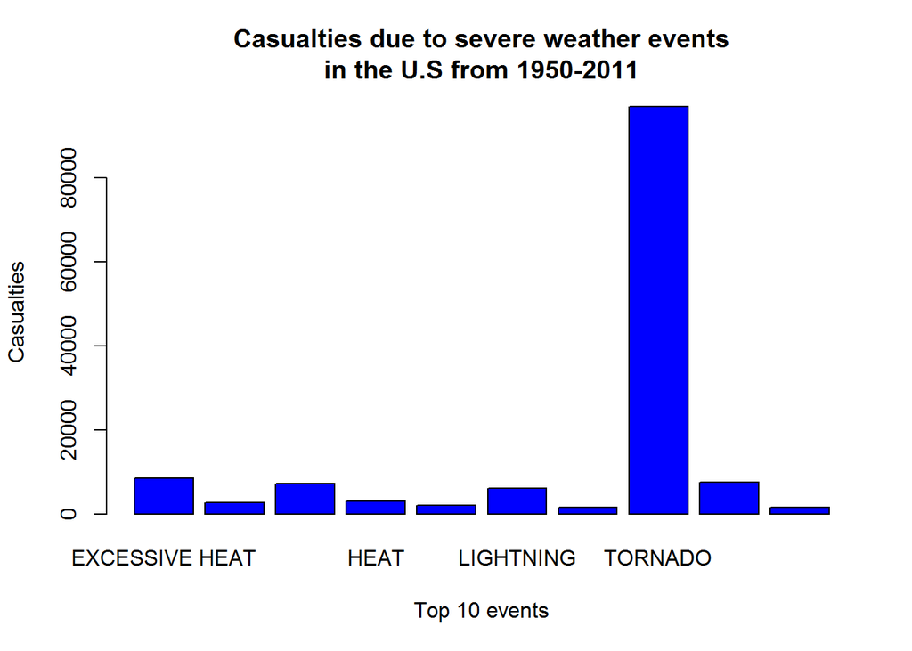

```r
barplot(info$total,names.arg=info$evtype, col="blue", xlab="Top 10 events",
        ylab="Casualties",main="Casualties due to severe weather events\nin the U.S from 1950-2011")
```

plot is based on the previous info using ggplot plotting system

[figure not shown]

```r
library(ggplot2)
p1 <- ggplot(data=info,
             aes(x=reorder(evtype, total), y=log10(total), fill=total )) +
    geom_bar(stat="identity") +
    coord_flip() +
    xlab("Event type") +
    ylab("Property damage in dollars (log-scale)")
p1 +  theme(legend.position="none")
```